# cool_notes

```python
from IPython.display import HTML

HTML('''<script>
code_show=true;
function code_toggle() {
 if (code_show){
 $('div.input').hide();
 } else {
 $('div.input').show();
 }
 code_show = !code_show
}
$( document ).ready(code_toggle);
</script>
<form action="javascript:code_toggle()"><input type="submit" value="Click here to toggle on/off the raw code."></form>''')
```

```python
import dill
%pylab inline

gal_check_2=dill.load(open('/home/aleksey/Dropbox/thesis/hydro_grid_2018/M1e+07_vw600.0_gamma0.8_rb100.0/eta_80.0_cool/grid.p'))
```

Showing an example run with cooling.

*Parameters*: $M_{\rm bh}=10^7 M_{\odot}$, $\rho_* \propto r^{-1.8}$, $v_w=600$ km s$^{-1}$. The stellar potential is on as well as heating from the stellar velocity dispersion (the influence radius is 3.5 pc, and for the stellar velocity dispersion we use the prescription in Generozov et al. 2015).

We start with a unrealistically high mass return rate to induce thermal instability--the mass source term $q=80 \rho_\star/t_h$.

First the solution without cooling is plotted below.

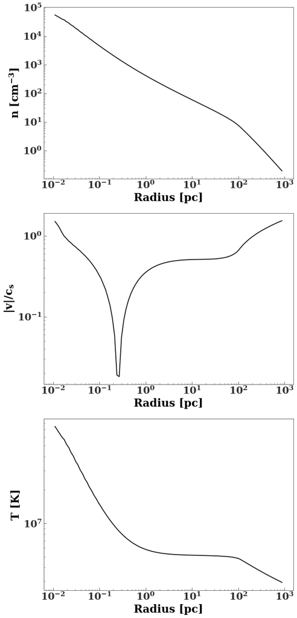

```python
gal_check_2.sol_plot(index=0)
```

For the cooling function we use the tabulated cooling function in Table 2 [Schure+2009](https://www.aanda.org/articles/aa/pdf/2009/47/aa12495-09.pdf)--for a solar metallicity gas. This is plotted below.

The cooling rate per unit volume is $n_e n_h \Lambda(T)$--though for consistency with Generozov+2015 we use $n^2 \Lambda(T)$, where n is the *total number density*

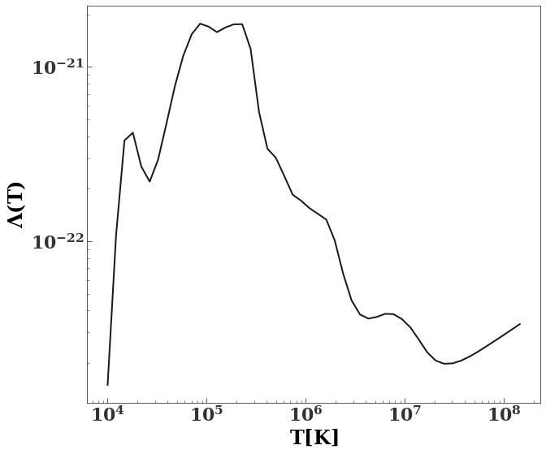

```python
from schure_cooling import cooling_curve

fig,ax=plt.subplots(figsize=(10,9))

ax.set_ylabel(r'$\Lambda(T)$')
ax.set_xlabel(r'$T [K]$')

temps=np.logspace(4, 8.16)
loglog(temps, cooling_curve.lambda_c(temps))
```

The movies below show how the temperature evolves when cooling is turned on (square shows the location of the stagnation radius). The total evolution time is 160 years...

[video not shown]

The below movies show how the ratio of the heating and cooling rates evolve in this run

[video not shown]

Plot summarizing the evolution of the density, Mach number and temperature...

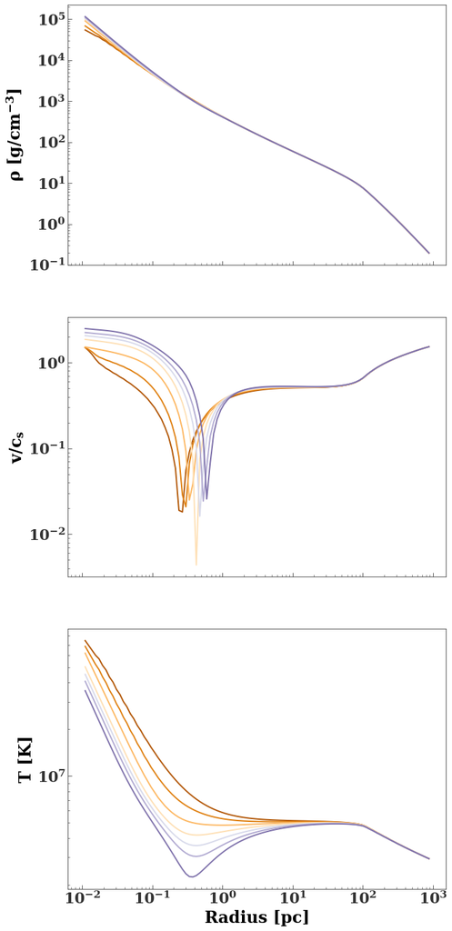

```python
gal_check_2.sol_plot_seq
```